# Practical 1.2: Importing Data Into R

Biotech 7005: Bioinformatics and Systems Modelling

Steven Delean (original material from Bioinformatics Hub, University of Adelaide)

28 July 2025

# Working With Data In R

## Data in the tidyverse

As well as forming objects like we did in the introductory session, we often import pre-existing data into R from a spreadsheet, and use this to perform an analysis. Sometimes we have to manipulate & ‘wrangle’ the data a little and as part of this. We also make plots to see what everything looks like as a common part of this process.

Today we’ll start the ball rolling by introducing a set of packages known as the `tidyverse`. This is a core set of packages produced by the RStudio team that make working with data as painless as possible. A brief introduction to these packages and the general approach is summarised below.

[figure not shown]

### Importing Data

Like most programming languages `R` is very strict about data formats. We can import `.xlsx`, `xls`, `csv`, `txt`, `gtf/gff` files + many more file types, but understanding the structure of the imported data is often required. For Excel files, some things we do to make it “look nice” in the Excel program can create problems, or are just ignored:

- Merged cells can lead to errors and unexpected results
- Specifying missing values can give misleading values
- Blank rows are not fatal, just annoying
- Cell formatting such as colour, fonts and cell-size will not be imported
- Plots will not be imported

**Before We Go On**

We first need to create a new script for this section. Save and close the first script we used, then create a new one

```
1. `File` > `New File` > `R Script` (Or `Ctrl++Alt+Shift+N`)
2. Save as `DataImport.R`
3. Enter this line at the top of the script
```

```r
library(tidyverse)
```

This strategy of loading packages at the start of your script using the command `library(packageName)`, is a best practice commonly used by R programmers. This will be helpful for any collaborators, and for yourself when you look back at a script in 6 months.

#### Using the GUI To Load Data

Now we’ve gone through some formalities, let’s import some data using the Graphical User Interface (GUI) that comes with RStudio

```
1. Navigate to your `Practical_1/data/intro_r` folder using the `Files` Tab
    - First click the ![](images/home.png) icon then click into `Practical_1`, then `data`, then `intro_r`
2. Click on the file `transport.csv`
3. Select `View File`
```

This can be used to open (small) files in the `Script Window` and view them as plain text files. When doing this **the file is not loaded into R**. However, it can be useful just to have a quick look at what the file contains. Here we can see that we have a series of comma-separated entries, which is what we expect for a `.csv` file.

Now close the file again by clicking the cross next to the file name in the Script Window.

To import the file, or more accurately, to import the data within the file into our `R Environment` we can either:

```
1. Click on the file and choose `Import Dataset`, or
2. Use the button as shown in the `Environment` Tab
```

Let’s use the first of these methods, so click on the file and choose `Import Dataset`. This will open the **Preview Window** as seen below. (If `Data Preview` is empty, click on the `Update` button.)

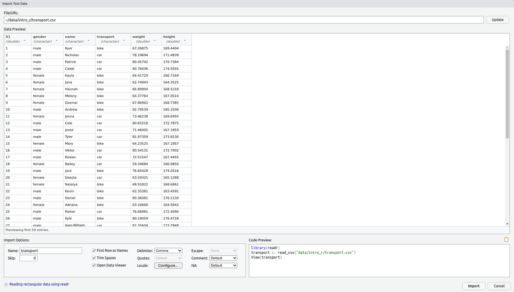

As highlighted in the circle below, this gives us a preview of the data as `R` will see it. This is helpful to check that the columns are as we expect. If there are problems with delimiters (sometimes files can be labeled `.csv` files but use a tab or semi-colon as delimiters) we will spot the problem here. If the column names are not as expected, we can also spot any problems here.

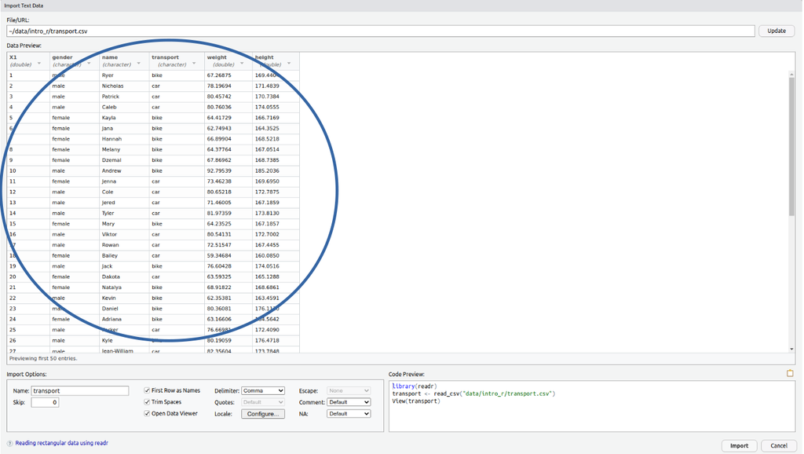

The Preview Window showing where we can see a preview of the data.

**A very important frame in this preview is the code highlighted in the bottom right corner.** This is the `R` code that is being executed to import the data. **Highlight this code with your mouse/touchpad and copy it to your clipboard.**

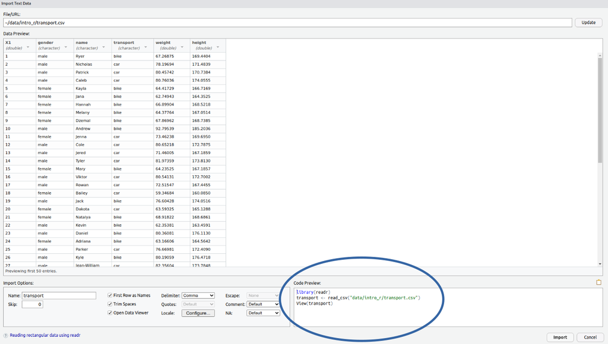

Once you have copied this code, click `Import` and the data will pop open inside `RStudio`. **Before you go any further, go to your `DataImport.R` script and paste the code directly below the line** `library(tidyverse)`.